# Árboles de clasificación basados en proyecciones y sus posibles extensiones

SIESTA, 19 de Marzo, 2019

## Presentación

Disponible en:https://natydasilva.github.io/PPtreeExtupdate/#1

Link en el repositorio de SIESTA: https://github.com/natydasilva/SIESTA

## Estructura de la charla

- Motivación
- Projection Pursuit
- Descripción de PPtree
- Aspectos menos deseables de PPtree
- Extensiones de PPtree
- Comentarios Finales

## Motivación

- Trabajo de PhD en bosques basados en proyecciones (Projection pursuit RF).
- Clasificador individual PPtree.
- Mejorar la performance de bosques mejorando los árboles individuales.

## Projection Pursuit

- PP es una técnica estadística para exploración para encontrar proyecciones de datos que revelen estructuras interesantes (Friedman and Tukey 1973).
- Los algoritmos de PP buscan proyecciones de bajas dimensiones optimizando un índice de proyección que mide si la proyección es útil en algún sentido.
- Pocos PP índices incorporan información de las clases para el cálculo.
- (Lee et al. 2005) proponen un índice derivado del análisis disciminante lineal útil para exploración en clasificación supervisada.

## PP_LDA

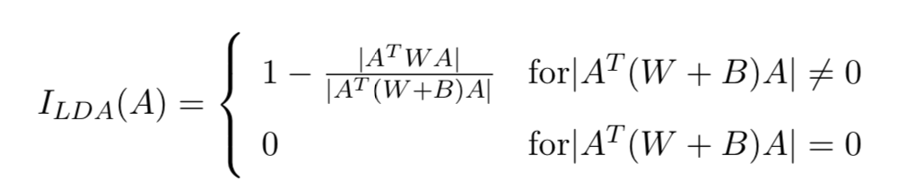

\(B\) es la suma de cuadrados entre grupos, \(W\) es la suma de cuadrados al interior del grupo y \(A\) es una matríz de proyección. Cuando es pequeño esperamos pequeñas diferencias entre clases.

## PP_PDA

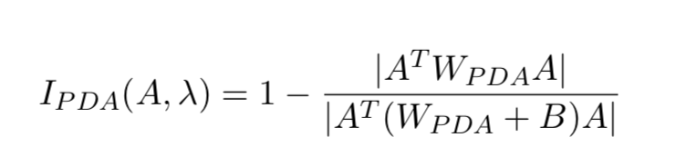

\(B^s\) suma de cuadrados entre grupos con los datos estandarizados, \(W^s\) es la suma de cuadrados al interior del grupo con los datos estandarizados y \(\lambda \in [0,1)\). Para problema \(p\) grande \(n\) pequeño.

## Projection pursuit

- PP quiere encontrar todas las proyecciones interesantes.
- No solamente un óptimo global ya que los optimos locales pueden revelear estucturas interesantes.

## PPtree

- **PPtree** (Lee et al. 2005) son árboles de clasificación basados en proyecciones.
- Combina métodos de árboles con reducción de dimensionalidad basada en proyecciones.
- Las particiones en **PPtree** se basan en combinaciones lineales de variables por lo que toma en cuenta la correlación entre las variables para separar las clases.

## PPtree

- Trata los datos siempre como un problema de dos clases.
- Cuando las clases son más de dos el algoritmo usas dos pasos de proyección optimizando un índice de proyección en cada partición del nodo.
- Los coeficientes de proyección en cada nodo representan la importancia de la variables, útiles para explorar como las clases son separadas en cada árbol.

## Algoritmo de PPtree

1. Optimiza un indice de proyección para encontrar una proyección \(1-D\) óptima, \(\alpha^*\), para separarar todas las classes obteniendo los datos proyectados \(z = \alpha^*x\)
2. En \(z\), dedefine el problema en uno de dos clases comparando medias y asigna una nueva etiqueta, \(g_1^*\) o \(g_2^*\) para cada observación, generando una nueva variable \(y_i^*\) para la clase.
3. Encuentra una proyección \(1-D\) óptima \(\alpha^{**}\), usando \(\{(\mathbf{x_i},y_i^*)\}_{i=1}^n\) para separar \(g_1^*\) y \(g_2^*\). La mejor separación y la regla de decisión para el nodo, si \(\alpha^{**T}M_1< c\) entonces asigna \(g_1^*\) al nodo izquierdo y en otro caso \(g_2^*\) al derecho, donde \(M_1\) es la media de \(g_1^*\).
4. Para cada grupo, todos los pasos previos son repetidos hasta que \(g_1^*\) y \(g_2^*\) tienen una sola clase de la clase original.

## Ilustración del algoritmo

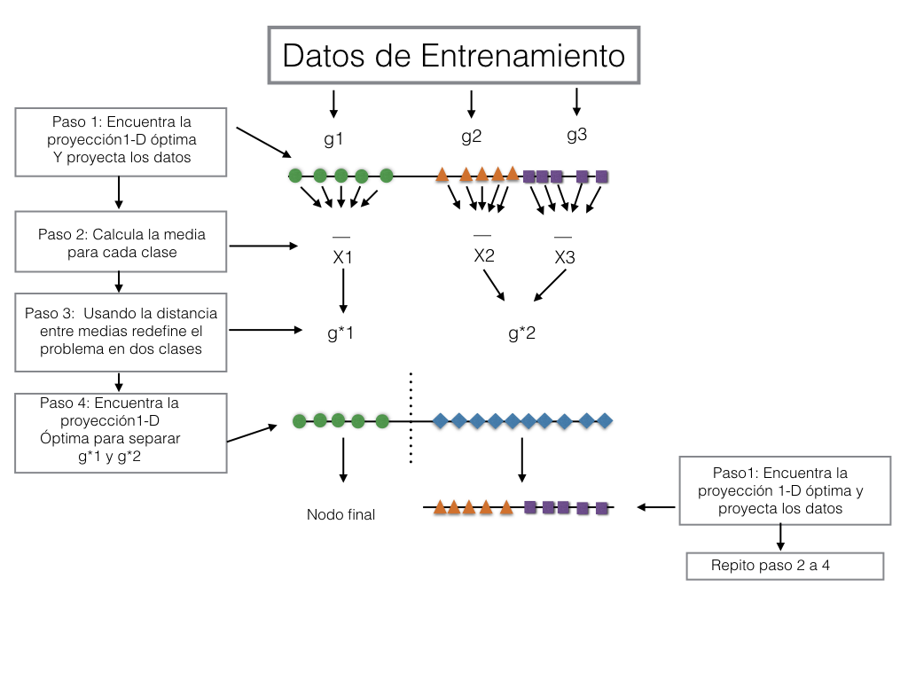

La profundidad del PPtree es como mucho el número de clases.

## PPtree, 8 reglas de corte

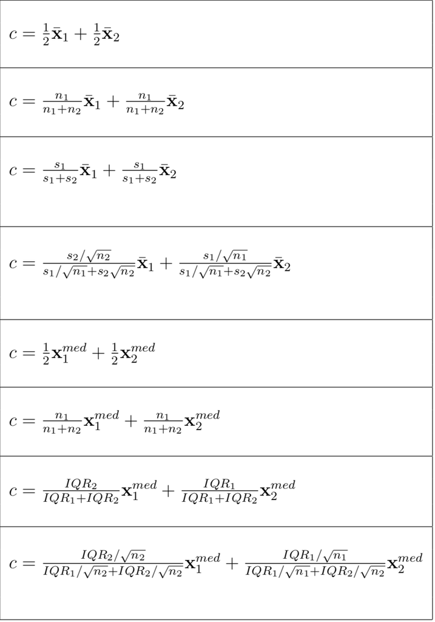

## Aspectos menos deseables: I

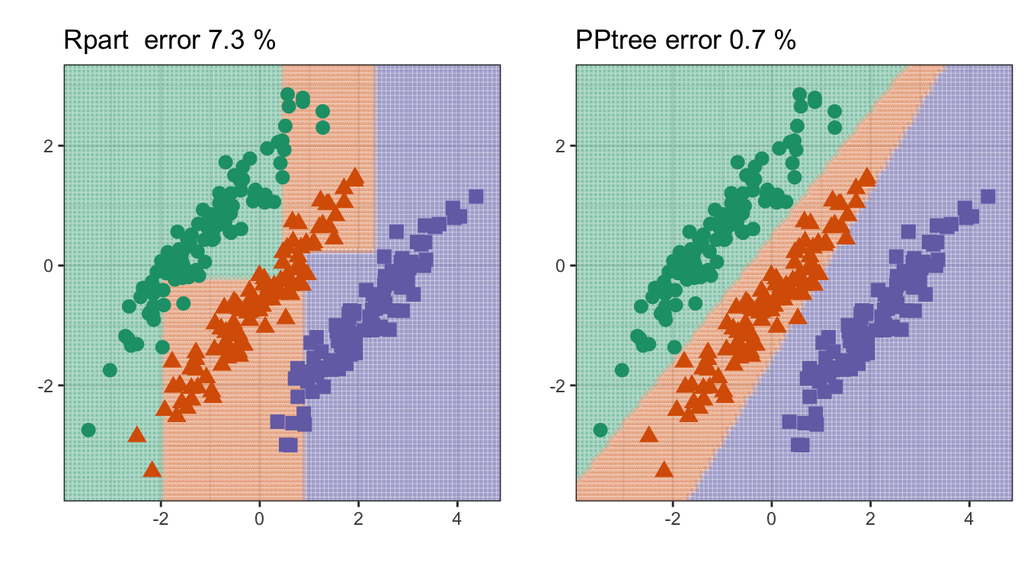

## Aspectos menos deseables: II

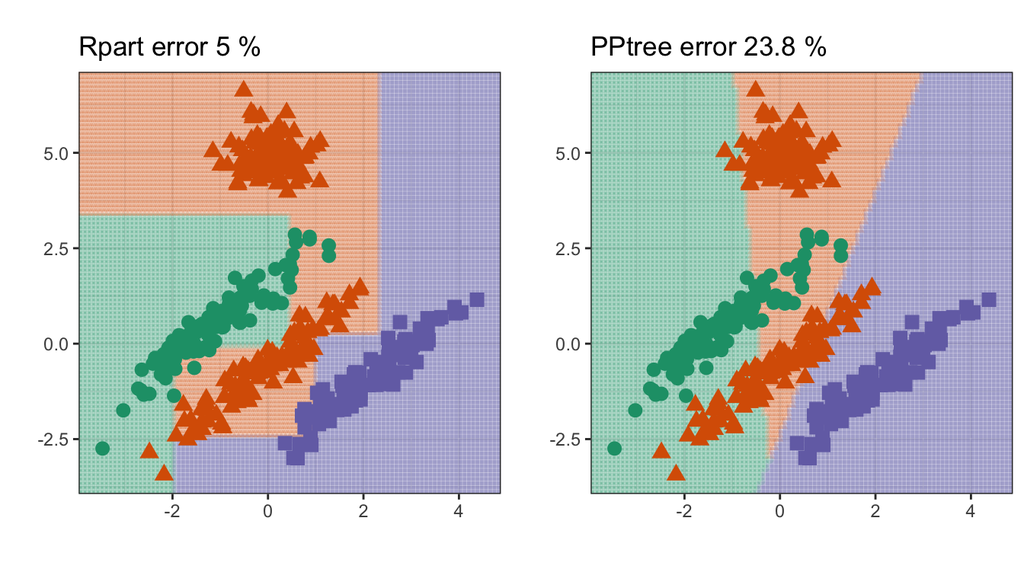

Los naranjas no pueden separarse por una única partición lineal y PPtree no puede modelar esto porque una clase es asignada solamente a un nodo terminal.

## Extensión: PPtree

Hay dos formas que el algoritmo ha sido modificado:

- Regla de decisión.
- Permitiendo particiones múltiples por grupos.
- Subdividir super-clase para producir valor de corte más apropiado.
- Para incrementar el número de particiones por grupos, reglas de parada adicional tienen que ser definidas.

## Extensión I: subdividiendo clases para producir mejores bandas

- La primer modificación se enfoca en el cuarto paso del algoritmo original.
- En vez de combinar clases en una super clase, unicamente las dos clases más cercanas son usadas para determinar la partición.

## PPtree extensión I

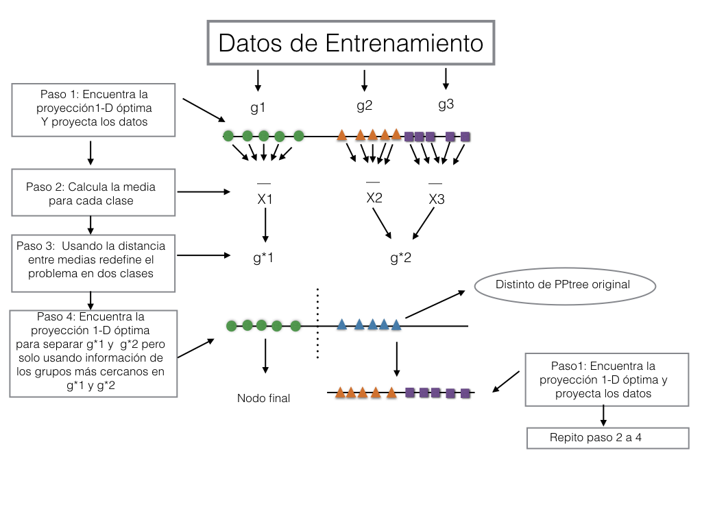

## Extensión II: permitiendo particiones múltiples por grupos

- La modificación introduce una nueva forma de seleccionar el valor de la partición basado en la impureza del grupo resultante.
- \(E(s)=-\sum_{j=1}^G p_{js}log(p_{js})\) donde \(p_{js}\) es la proporción de puntos de la clase \(j\) en el subconjunto \(s\) y \(G\) el número de clases.
- \(E(s)\) grande indican grupos mezclados, impuros.
- \(E(s)=0\) grupo puro.

## PPtree extension II

- Para determinar la calidad de la partición se debe considerar el lado izquierdo y derecho de la partición.
- \(E(s_L, s_R) = \frac{n_L}{n_L+n_R}E(s_L)+\frac{n_R}{n_L+n_R}E(s_R)\)
- \(E(s_L, s_R)\) se calcula para cada posible partición y la que tiene la mínima impureza determina \(c\) el corte.
- Esta modificación cambia dramáticamente el algoritmo de PPtree con el objetivo de flexibilizarlo a clasificador no lineal permitiendo muchas particiones por clase.
- Necesitamos determinar reglas de parada.

## PPtree extension II

1. Optimiza un índice de proyección para encontr la proyección \(1-D\) óptima \(\alpha^*\) para separar todas las clases en los datos.
2. Con los datos proyectados calcula la entropía para cada posible particción. Las posibles particiones son definidas entre cada valor proyectado.
3. Selecciona la mejor partición que minimiza \(E(s_L, s_R)\).
4. Repite los pasos anteriores hasta que la regla de parada se satisface.

## PPtree extensión II regla de parada

La regla de parada controla cuando el crecimiento del árbol debe parar. Las siguientes reglas de parada son usadas:

- Si un nodo es puro; todos los casos son de la misma clase en un nodo.
- Si el tamaño del nodo es menos que un valor menor a un valor determinado \(n_S\).
- Si la reducción de la entropía de una partición es menos que un valor especificado \(ent_s\).

## Ilustración de la extensión II

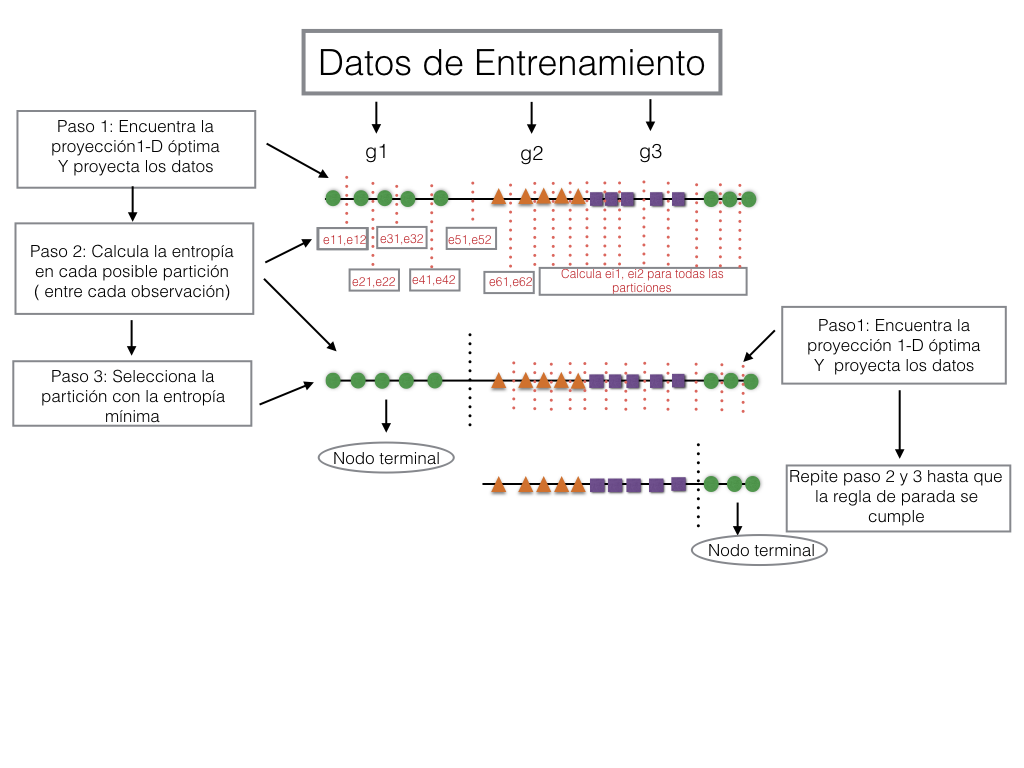

## Comparación de algoritmos

- Comparamos los métodos usando shiny (Chang et al. 2015) que nos permite incluir datos simulados y definir las bandas de cada algoritmo de forma interactiva.
- Se incluyen distintos métodos para simular datos 2D y las bandas definidad por los distintos algoritmos se muestra.

## Comparación de algoritmos

- Hay tres pestañas que controlan los distintos tipos de datos simulados.
- 1 mixtura multivariada con igual matriz de var-cov para los grupos y diff media.
- Incluye un grupo con outliers.
- Simulación de mixturas con el paquete `MixSim`.

## Panel 1: Simulación básica de 3 clases

[video not shown]

## Panel 2: Simulación con Outliers

[video not shown]

## Panel 3: Simulaciones con MixSim pkg

[video not shown]

## Paquete PPtreeExt

- Paquete en R PPtreeExt en etapa de desarrollo
- Disponible en https://github.com/natydasilva/PPtreeExt
- Deseable incluirlo en el paquete PPtree disponible en CRAN

## Comentarios Finales

- Se presentaron dos posibles modificaciones en el algoritmo de PPTree para hacerlo más flexible.
- Se examinaron las modificaciones mediante una shiny app.
- Los resultados primarios muestran un algoritmo de clasificación más flexibles utilizando combinaciones de variables.
- The shiny ilustra la simplicidad de constuir una herramienta para explorar resultados primarios en la modificacioón del algoritmo
- Implementado en un paquete en R.

## Trabajo futuro

- Comparar la performance de PPtree con sus posibles extensiones con datos simulados y reales
- Con los nuevos árboles extender PPforest
- ….

Chang, Winston, Joe Cheng, J Allaire, Yihui Xie, and Jonathan McPherson. 2015. “Shiny: Web Application Framework for R, R Package Version 0.11.” http://CRAN.R-project.org/package=shiny.

Friedman, Jerome H, and John W Tukey. 1973. “A Projection Pursuit Algorithm for Exploratory Data Analysis.”

Lee, Eun-Kyung, Dianne Cook, Sigbert Klinke, and Thomas Lumley. 2005. “Projection Pursuit for Exploratory Supervised Classification.” *Journal of Computational and Graphical Statistics* 14 (4).